# Risk Factor Analysis

## Outcome Variable

**Outcome Variable:** whz

## Predictor Variables

**Intervention Variable:** nchldlt5

**Adjustment Set:**

- arm
- W_mage
- meducyrs
- feducyrs
- hhwealth_quart
- hfoodsec
- W_mhtcm
- W_nrooms
- W_parity
- impfloor
- impsan
- safeh20
- delta_W_mage
- delta_meducyrs
- delta_feducyrs
- delta_hhwealth_quart
- delta_hfoodsec
- delta_W_mhtcm
- delta_W_nrooms
- delta_W_parity
- delta_impfloor
- delta_impsan
- delta_safeh20

## Stratifying Variables

The analysis was stratified on these variable(s):

- agecat
- studyid
- country

## Data Summary

| agecat | studyid | country | nchldlt5 | n_cell | n |
| --- | --- | --- | --- | --- | --- |
| Birth | ki1000108-IRC | INDIA | 1 | 72 | 343 |
| Birth | ki1000108-IRC | INDIA | 2+ | 271 | 343 |
| Birth | ki1017093c-NIH-Crypto | BANGLADESH | 1 | 15 | 23 |
| Birth | ki1017093c-NIH-Crypto | BANGLADESH | 2+ | 8 | 23 |
| Birth | kiGH5241-JiVitA-3 | BANGLADESH | 1 | 9384 | 15688 |
| Birth | kiGH5241-JiVitA-3 | BANGLADESH | 2+ | 6304 | 15688 |
| 6 months | ki1000108-IRC | INDIA | 1 | 88 | 408 |
| 6 months | ki1000108-IRC | INDIA | 2+ | 320 | 408 |
| 6 months | ki1017093b-PROVIDE | BANGLADESH | 1 | 426 | 582 |
| 6 months | ki1017093b-PROVIDE | BANGLADESH | 2+ | 156 | 582 |
| 6 months | ki1017093c-NIH-Crypto | BANGLADESH | 1 | 507 | 715 |
| 6 months | ki1017093c-NIH-Crypto | BANGLADESH | 2+ | 208 | 715 |
| 6 months | ki1066203-TanzaniaChild2 | TANZANIA, UNITED REPUBLIC OF | 1 | 1390 | 2019 |
| 6 months | ki1066203-TanzaniaChild2 | TANZANIA, UNITED REPUBLIC OF | 2+ | 629 | 2019 |
| 6 months | ki1148112-LCNI-5 | MALAWI | 1 | 390 | 811 |
| 6 months | ki1148112-LCNI-5 | MALAWI | 2+ | 421 | 811 |
| 6 months | kiGH5241-JiVitA-3 | BANGLADESH | 1 | 10872 | 16773 |
| 6 months | kiGH5241-JiVitA-3 | BANGLADESH | 2+ | 5901 | 16773 |
| 24 months | ki1000108-IRC | INDIA | 1 | 89 | 409 |
| 24 months | ki1000108-IRC | INDIA | 2+ | 320 | 409 |
| 24 months | ki1017093b-PROVIDE | BANGLADESH | 1 | 423 | 578 |
| 24 months | ki1017093b-PROVIDE | BANGLADESH | 2+ | 155 | 578 |
| 24 months | ki1017093c-NIH-Crypto | BANGLADESH | 1 | 357 | 514 |
| 24 months | ki1017093c-NIH-Crypto | BANGLADESH | 2+ | 157 | 514 |
| 24 months | ki1066203-TanzaniaChild2 | TANZANIA, UNITED REPUBLIC OF | 1 | 5 | 6 |
| 24 months | ki1066203-TanzaniaChild2 | TANZANIA, UNITED REPUBLIC OF | 2+ | 1 | 6 |
| 24 months | ki1148112-LCNI-5 | MALAWI | 1 | 277 | 555 |
| 24 months | ki1148112-LCNI-5 | MALAWI | 2+ | 278 | 555 |
| 24 months | kiGH5241-JiVitA-3 | BANGLADESH | 1 | 5434 | 8593 |
| 24 months | kiGH5241-JiVitA-3 | BANGLADESH | 2+ | 3159 | 8593 |

The following strata were considered:

- agecat: 24 months, studyid: ki1000108-IRC, country: INDIA
- agecat: 24 months, studyid: ki1017093b-PROVIDE, country: BANGLADESH
- agecat: 24 months, studyid: ki1017093c-NIH-Crypto, country: BANGLADESH
- agecat: 24 months, studyid: ki1066203-TanzaniaChild2, country: TANZANIA, UNITED REPUBLIC OF
- agecat: 24 months, studyid: ki1148112-LCNI-5, country: MALAWI
- agecat: 24 months, studyid: kiGH5241-JiVitA-3, country: BANGLADESH
- agecat: 6 months, studyid: ki1000108-IRC, country: INDIA
- agecat: 6 months, studyid: ki1017093b-PROVIDE, country: BANGLADESH
- agecat: 6 months, studyid: ki1017093c-NIH-Crypto, country: BANGLADESH
- agecat: 6 months, studyid: ki1066203-TanzaniaChild2, country: TANZANIA, UNITED REPUBLIC OF
- agecat: 6 months, studyid: ki1148112-LCNI-5, country: MALAWI
- agecat: 6 months, studyid: kiGH5241-JiVitA-3, country: BANGLADESH
- agecat: Birth, studyid: ki1000108-IRC, country: INDIA
- agecat: Birth, studyid: ki1017093c-NIH-Crypto, country: BANGLADESH
- agecat: Birth, studyid: kiGH5241-JiVitA-3, country: BANGLADESH

### Dropped Strata

Some strata were dropped due to rare outcomes:

- agecat: 24 months, studyid: ki1066203-TanzaniaChild2, country: TANZANIA, UNITED REPUBLIC OF

## Methods Detail

We’re interested in the causal parameters $E[Y_a]$ for all values of $a \in \mathcal{A}$. These parameters represent the mean outcome if, possibly contrary to fact, we intervened to set all units to have $A=a$. Under the randomization and positivity assumptions, these are identified by the statistical parameters $\psi_a=E_W[E_{Y|A,W}(Y|A=a,W)]$. In addition, we’re interested in the mean of $Y$, $E[Y]$ under no intervention (the observed mean). We will estimate these parameters by using SuperLearner to fit the relevant likelihood factors – $E_{Y|A,W}(Y|A=a,W)$ and $p(A=a|W)$, and then updating our likelihood fit using a joint TMLE.

For unadjusted analyses ($W=\{\}$), initial likelihoods were estimated using Lrnr_glm to estimate the simple $E(Y|A)$ and Lrnr_mean to estimate $p(A)$. For adjusted analyses, a small library containing Lrnr_glmnet, Lrnr_xgboost, and Lrnr_mean was used.

Having estimated these parameters, we will then use the delta method to estimate relative risks and attributable risks relative to a prespecified baseline level of $A$.

# Results Detail

## Results Plots

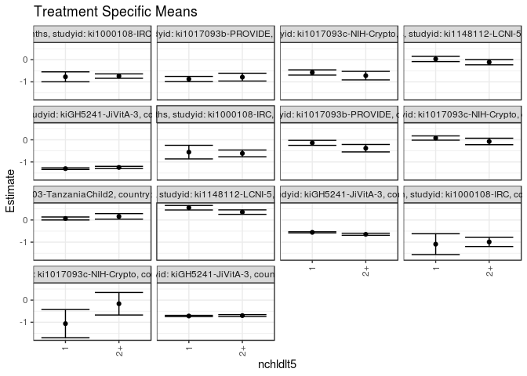

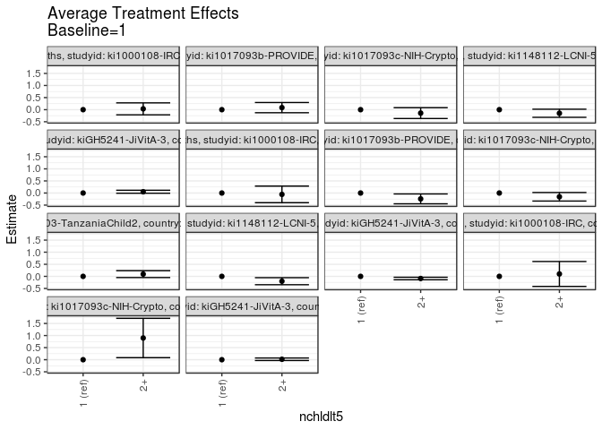

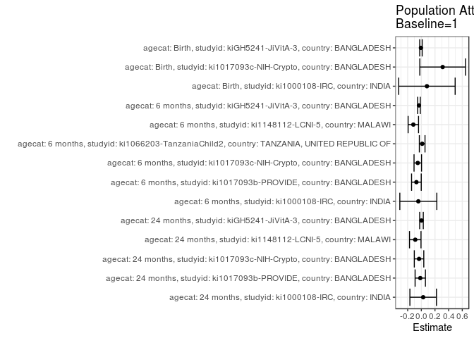

## Results Table

### Parameter: TSM

| agecat | studyid | country | intervention_level | baseline_level | estimate | ci_lower | ci_upper |
| --- | --- | --- | --- | --- | --- | --- | --- |
| Birth | ki1000108-IRC | INDIA | 1 | NA | -1.0927551 | -1.5631389 | -0.6223714 |
| Birth | ki1000108-IRC | INDIA | 2+ | NA | -0.9925803 | -1.1994685 | -0.7856921 |
| Birth | ki1017093c-NIH-Crypto | BANGLADESH | 1 | NA | -1.0633333 | -1.6993429 | -0.4273238 |
| Birth | ki1017093c-NIH-Crypto | BANGLADESH | 2+ | NA | -0.1650000 | -0.6730802 | 0.3430802 |
| Birth | kiGH5241-JiVitA-3 | BANGLADESH | 1 | NA | -0.7183101 | -0.7464977 | -0.6901224 |
| Birth | kiGH5241-JiVitA-3 | BANGLADESH | 2+ | NA | -0.6998890 | -0.7435955 | -0.6561825 |
| 6 months | ki1000108-IRC | INDIA | 1 | NA | -0.5549424 | -0.8624457 | -0.2474392 |
| 6 months | ki1000108-IRC | INDIA | 2+ | NA | -0.6116660 | -0.7636396 | -0.4596923 |
| 6 months | ki1017093b-PROVIDE | BANGLADESH | 1 | NA | -0.1362845 | -0.2494737 | -0.0230954 |
| 6 months | ki1017093b-PROVIDE | BANGLADESH | 2+ | NA | -0.3778284 | -0.5453343 | -0.2103226 |
| 6 months | ki1017093c-NIH-Crypto | BANGLADESH | 1 | NA | 0.0817663 | -0.0148021 | 0.1783348 |
| 6 months | ki1017093c-NIH-Crypto | BANGLADESH | 2+ | NA | -0.0735178 | -0.2199659 | 0.0729303 |
| 6 months | ki1066203-TanzaniaChild2 | TANZANIA, UNITED REPUBLIC OF | 1 | NA | 0.0675981 | 0.0005609 | 0.1346354 |
| 6 months | ki1066203-TanzaniaChild2 | TANZANIA, UNITED REPUBLIC OF | 2+ | NA | 0.1608321 | 0.0346055 | 0.2870588 |
| 6 months | ki1148112-LCNI-5 | MALAWI | 1 | NA | 0.5550724 | 0.4521756 | 0.6579692 |
| 6 months | ki1148112-LCNI-5 | MALAWI | 2+ | NA | 0.3551049 | 0.2540326 | 0.4561773 |
| 6 months | kiGH5241-JiVitA-3 | BANGLADESH | 1 | NA | -0.5587740 | -0.5864287 | -0.5311193 |
| 6 months | kiGH5241-JiVitA-3 | BANGLADESH | 2+ | NA | -0.6473058 | -0.6918740 | -0.6027376 |
| 24 months | ki1000108-IRC | INDIA | 1 | NA | -0.7730871 | -0.9979697 | -0.5482045 |
| 24 months | ki1000108-IRC | INDIA | 2+ | NA | -0.7386177 | -0.8386101 | -0.6386252 |
| 24 months | ki1017093b-PROVIDE | BANGLADESH | 1 | NA | -0.8724321 | -0.9908062 | -0.7540580 |
| 24 months | ki1017093b-PROVIDE | BANGLADESH | 2+ | NA | -0.7868156 | -0.9620856 | -0.6115457 |
| 24 months | ki1017093c-NIH-Crypto | BANGLADESH | 1 | NA | -0.5769688 | -0.6949228 | -0.4590147 |
| 24 months | ki1017093c-NIH-Crypto | BANGLADESH | 2+ | NA | -0.7186473 | -0.9106108 | -0.5266839 |
| 24 months | ki1148112-LCNI-5 | MALAWI | 1 | NA | 0.0341761 | -0.0834005 | 0.1517527 |
| 24 months | ki1148112-LCNI-5 | MALAWI | 2+ | NA | -0.1135947 | -0.2309422 | 0.0037528 |
| 24 months | kiGH5241-JiVitA-3 | BANGLADESH | 1 | NA | -1.2995714 | -1.3355215 | -1.2636213 |
| 24 months | kiGH5241-JiVitA-3 | BANGLADESH | 2+ | NA | -1.2471966 | -1.2985503 | -1.1958430 |

### Parameter: E(Y)

| agecat | studyid | country | intervention_level | baseline_level | estimate | ci_lower | ci_upper |
| --- | --- | --- | --- | --- | --- | --- | --- |
| Birth | ki1000108-IRC | INDIA | NA | NA | -1.0105831 | -1.1973019 | -0.8238643 |
| Birth | ki1017093c-NIH-Crypto | BANGLADESH | NA | NA | -0.7508696 | -1.2358912 | -0.2658480 |
| Birth | kiGH5241-JiVitA-3 | BANGLADESH | NA | NA | -0.7238781 | -0.7437238 | -0.7040324 |
| 6 months | ki1000108-IRC | INDIA | NA | NA | -0.5989297 | -0.7344491 | -0.4634104 |
| 6 months | ki1017093b-PROVIDE | BANGLADESH | NA | NA | -0.2083706 | -0.2927992 | -0.1239419 |
| 6 months | ki1017093c-NIH-Crypto | BANGLADESH | NA | NA | 0.0297622 | -0.0491685 | 0.1086930 |
| 6 months | ki1066203-TanzaniaChild2 | TANZANIA, UNITED REPUBLIC OF | NA | NA | 0.0801680 | 0.0273223 | 0.1330136 |
| 6 months | ki1148112-LCNI-5 | MALAWI | NA | NA | 0.4379901 | 0.3664653 | 0.5095150 |
| 6 months | kiGH5241-JiVitA-3 | BANGLADESH | NA | NA | -0.5932472 | -0.6127728 | -0.5737215 |
| 24 months | ki1000108-IRC | INDIA | NA | NA | -0.7458150 | -0.8368180 | -0.6548120 |
| 24 months | ki1017093b-PROVIDE | BANGLADESH | NA | NA | -0.8879412 | -0.9708680 | -0.8050144 |
| 24 months | ki1017093c-NIH-Crypto | BANGLADESH | NA | NA | -0.6103502 | -0.7050157 | -0.5156847 |
| 24 months | ki1148112-LCNI-5 | MALAWI | NA | NA | -0.0548108 | -0.1370859 | 0.0274643 |
| 24 months | kiGH5241-JiVitA-3 | BANGLADESH | NA | NA | -1.2972908 | -1.3206179 | -1.2739638 |

### Parameter: ATE

| agecat | studyid | country | intervention_level | baseline_level | estimate | ci_lower | ci_upper |
| --- | --- | --- | --- | --- | --- | --- | --- |
| Birth | ki1000108-IRC | INDIA | 1 | 1 | 0.0000000 | 0.0000000 | 0.0000000 |
| Birth | ki1000108-IRC | INDIA | 2+ | 1 | 0.1001749 | -0.4147995 | 0.6151492 |
| Birth | ki1017093c-NIH-Crypto | BANGLADESH | 1 | 1 | 0.0000000 | 0.0000000 | 0.0000000 |
| Birth | ki1017093c-NIH-Crypto | BANGLADESH | 2+ | 1 | 0.8983333 | 0.0842979 | 1.7123687 |
| Birth | kiGH5241-JiVitA-3 | BANGLADESH | 1 | 1 | 0.0000000 | 0.0000000 | 0.0000000 |
| Birth | kiGH5241-JiVitA-3 | BANGLADESH | 2+ | 1 | 0.0184211 | -0.0335084 | 0.0703505 |
| 6 months | ki1000108-IRC | INDIA | 1 | 1 | 0.0000000 | 0.0000000 | 0.0000000 |
| 6 months | ki1000108-IRC | INDIA | 2+ | 1 | -0.0567235 | -0.4001734 | 0.2867263 |
| 6 months | ki1017093b-PROVIDE | BANGLADESH | 1 | 1 | 0.0000000 | 0.0000000 | 0.0000000 |
| 6 months | ki1017093b-PROVIDE | BANGLADESH | 2+ | 1 | -0.2415439 | -0.4450526 | -0.0380353 |
| 6 months | ki1017093c-NIH-Crypto | BANGLADESH | 1 | 1 | 0.0000000 | 0.0000000 | 0.0000000 |
| 6 months | ki1017093c-NIH-Crypto | BANGLADESH | 2+ | 1 | -0.1552841 | -0.3323104 | 0.0217422 |
| 6 months | ki1066203-TanzaniaChild2 | TANZANIA, UNITED REPUBLIC OF | 1 | 1 | 0.0000000 | 0.0000000 | 0.0000000 |
| 6 months | ki1066203-TanzaniaChild2 | TANZANIA, UNITED REPUBLIC OF | 2+ | 1 | 0.0932340 | -0.0500119 | 0.2364800 |
| 6 months | ki1148112-LCNI-5 | MALAWI | 1 | 1 | 0.0000000 | 0.0000000 | 0.0000000 |
| 6 months | ki1148112-LCNI-5 | MALAWI | 2+ | 1 | -0.1999675 | -0.3450215 | -0.0549135 |
| 6 months | kiGH5241-JiVitA-3 | BANGLADESH | 1 | 1 | 0.0000000 | 0.0000000 | 0.0000000 |
| 6 months | kiGH5241-JiVitA-3 | BANGLADESH | 2+ | 1 | -0.0885318 | -0.1404161 | -0.0366475 |
| 24 months | ki1000108-IRC | INDIA | 1 | 1 | 0.0000000 | 0.0000000 | 0.0000000 |
| 24 months | ki1000108-IRC | INDIA | 2+ | 1 | 0.0344695 | -0.2118935 | 0.2808325 |
| 24 months | ki1017093b-PROVIDE | BANGLADESH | 1 | 1 | 0.0000000 | 0.0000000 | 0.0000000 |
| 24 months | ki1017093b-PROVIDE | BANGLADESH | 2+ | 1 | 0.0856164 | -0.1254563 | 0.2966892 |
| 24 months | ki1017093c-NIH-Crypto | BANGLADESH | 1 | 1 | 0.0000000 | 0.0000000 | 0.0000000 |
| 24 months | ki1017093c-NIH-Crypto | BANGLADESH | 2+ | 1 | -0.1416785 | -0.3657603 | 0.0824032 |
| 24 months | ki1148112-LCNI-5 | MALAWI | 1 | 1 | 0.0000000 | 0.0000000 | 0.0000000 |
| 24 months | ki1148112-LCNI-5 | MALAWI | 2+ | 1 | -0.1477708 | -0.3154650 | 0.0199235 |
| 24 months | kiGH5241-JiVitA-3 | BANGLADESH | 1 | 1 | 0.0000000 | 0.0000000 | 0.0000000 |
| 24 months | kiGH5241-JiVitA-3 | BANGLADESH | 2+ | 1 | 0.0523748 | -0.0091671 | 0.1139167 |

### Parameter: PAR

| agecat | studyid | country | intervention_level | baseline_level | estimate | ci_lower | ci_upper |
| --- | --- | --- | --- | --- | --- | --- | --- |
| Birth | ki1000108-IRC | INDIA | 1 | NA | 0.0821720 | -0.3313333 | 0.4956774 |
| Birth | ki1017093c-NIH-Crypto | BANGLADESH | 1 | NA | 0.3124638 | -0.0224015 | 0.6473291 |
| Birth | kiGH5241-JiVitA-3 | BANGLADESH | 1 | NA | -0.0055681 | -0.0237798 | 0.0126437 |
| 6 months | ki1000108-IRC | INDIA | 1 | NA | -0.0439873 | -0.3150789 | 0.2271043 |
| 6 months | ki1017093b-PROVIDE | BANGLADESH | 1 | NA | -0.0720861 | -0.1430665 | -0.0011056 |
| 6 months | ki1017093c-NIH-Crypto | BANGLADESH | 1 | NA | -0.0520041 | -0.1069496 | 0.0029414 |
| 6 months | ki1066203-TanzaniaChild2 | TANZANIA, UNITED REPUBLIC OF | 1 | NA | 0.0125699 | -0.0287881 | 0.0539278 |
| 6 months | ki1148112-LCNI-5 | MALAWI | 1 | NA | -0.1170823 | -0.1934169 | -0.0407476 |
| 6 months | kiGH5241-JiVitA-3 | BANGLADESH | 1 | NA | -0.0344732 | -0.0537448 | -0.0152015 |
| 24 months | ki1000108-IRC | INDIA | 1 | NA | 0.0272721 | -0.1674741 | 0.2220183 |
| 24 months | ki1017093b-PROVIDE | BANGLADESH | 1 | NA | -0.0155091 | -0.0910601 | 0.0600419 |
| 24 months | ki1017093c-NIH-Crypto | BANGLADESH | 1 | NA | -0.0333814 | -0.1028811 | 0.0361183 |
| 24 months | ki1148112-LCNI-5 | MALAWI | 1 | NA | -0.0889869 | -0.1732103 | -0.0047635 |
| 24 months | kiGH5241-JiVitA-3 | BANGLADESH | 1 | NA | 0.0022806 | -0.0240934 | 0.0286546 |